# PracMachineLearning Assignment

leighgoodenough

23/05/2020

## Executive Summary

This report outlines a method of exploring & fitting a model to accelerometer data on six subjects undertaking the Unilateral Dumbbell Biceps Curl exercise. The training data is divided into five groupings, with one group of exercises being performed correctly and the other four groupings representing incorrect methods of undertaking the exercise. Exploratory Data Analysis showed which of the 52 measurements taken were significantky variant between the five groupings. A random forests model was fitted to training data with approx. 95% accuracy. When this model was fitted to the test data, 20 out of 20 observations were predicted correctly.

### Loading and Preprocessing Data

The caret library in R will be accessed for this project. The training and testing files are sourced online and saved to the working directory.

```r
## Load required packages
library(caret)
```

```r
## Download and read in the source files - training and testing
trainURL <- "https://d396qusza40orc.cloudfront.net/predmachlearn/pml-training.csv"
testURL <- "https://d396qusza40orc.cloudfront.net/predmachlearn/pml-testing.csv"
download.file(trainURL,destfile="training.csv")
download.file(testURL,destfile="testing.csv")
training <- read.csv("training.csv")
test <- read.csv("testing.csv")
```

### Preprocessing data

Early exploration of the data quickly identified that of 160 columns of data, only 60 contained data of any substance. Of these, 52 involved measurements that could be utilised for modelling. The final column in the training data illustrated the ‘classe’ factor for grouping the five different ways in which the exercise was performed. The final column of the testing data showed the problem id. Training and testing datasets were subset to the columns containing data.

```r
## Subset dataframes to columns with data
training <- training[,c(1:11,37:49,60:68,84:86,102,113:124,140,151:160)]
test <- test[,c(1:11,37:49,60:68,84:86,102,113:124,140,151:160)]
dim(training); dim(test)
```

```
## [1] 19622    60
```

```
## [1] 20 60
```

```r
table(training$classe)
```

```
##
##    A    B    C    D    E
## 5580 3797 3422 3216 3607
```

### Exploratory Data Analysis

A boxplot was created for each of the 52 accelererometer measures, grouped by classe. This showed that many measurements were closely correlated across the five classe groupings. A smaller number of measurements showed significant variation, indicating that they would be more useful for model fitting than others. Some of the examples of boxplots showing variation are shown in the figure below.

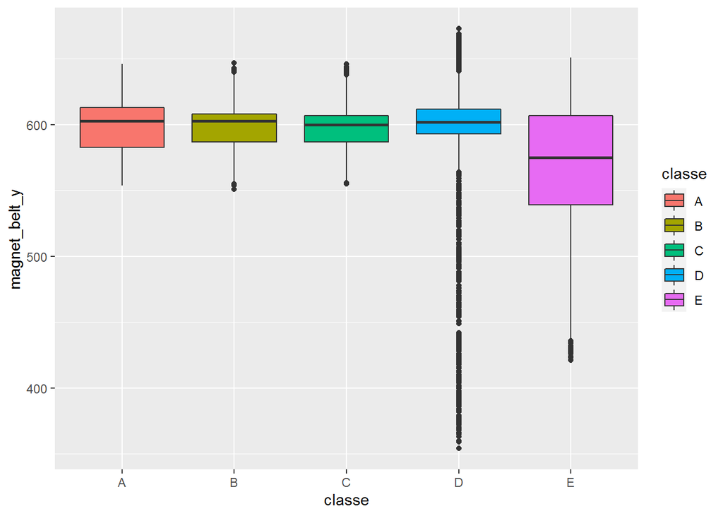

```r
## template for EDA boxplot for each covariate
qplot(classe,magnet_belt_y,data=training,fill=classe,geom=c("boxplot"))
```

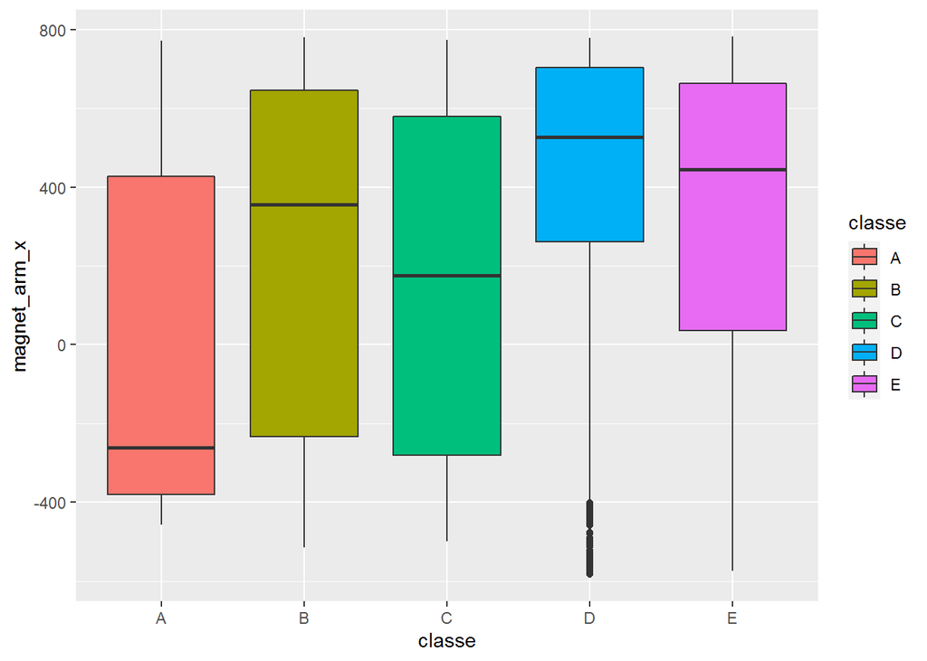

```r
qplot(classe,magnet_arm_x,data=training,fill=classe,geom=c("boxplot"))
```

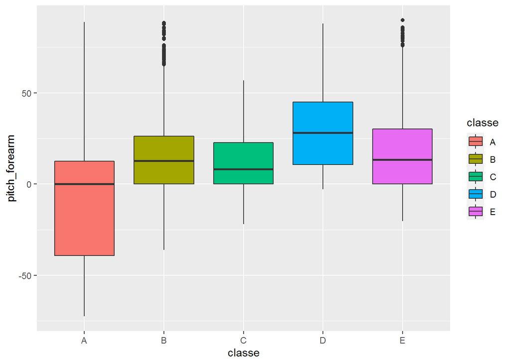

```r
qplot(classe,pitch_forearm,data=training,fill=classe,geom=c("boxplot"))
```

### Data splitting and further processing

The training data set was split into two groupings, 70% for training the model and 30% to act as a probe dataset in preparation for applying the model to the test set.

Based on the results of plotting each accelererometer variable, ten covariates were selected due to significant variation between classe groupings, and the training and probe sets were further subsetted to these columns of data.

```r
## Split train dataset into training and testing data
set.seed(2020)
inTrain <- createDataPartition(y=training$classe, p=0.7, list=FALSE)
training <- training[inTrain,]
testing <- training[-inTrain,]

## Subset to columns with high variance (rel. low correlation) between classe factors
training2 <- training[,c(19,31,32,33,34,44,45,48,54,58,60)]
testing2 <- testing[,c(19,31,32,33,34,44,45,48,54,58,60)]
```

### Model fitting and testing on probe set

A random forest model was fitted to the training data, using k-fold cross-validation. The random forest method was chosen due to its applicability to datasets with large numbers of variables. It was also noted that this was the method utilised by the creators of the datest to test the accuracy of their data.

The model showed a 5% error rate upon analysis of the final model, and 100% accuracy when applied to the probe set.

```r
## Predict results for probe testing set within training data
train.control <- trainControl(method = "cv", number = 5)
fit2 <- train(classe~., data=training2, method="rf", trControl = train.control)
fit2$finalModel
```

```
##
## Call:
##  randomForest(x = x, y = y, mtry = param$mtry)
##                Type of random forest: classification
##                      Number of trees: 500
## No. of variables tried at each split: 2
##
##         OOB estimate of  error rate: 5.31%
## Confusion matrix:
##      A    B    C    D    E class.error
## A 3834   26   13   24    9  0.01843318
## B  111 2424   89   20   14  0.08803612
## C   25   56 2291   13   11  0.04382304
## D   42    8  103 2083   16  0.07504440
## E   22   63   28   36 2376  0.05900990
```

```r
pred3 <- predict(fit2,testing2)
testing2$pred2Right <- pred3==testing2$classe
table(pred3,testing2$classe)
```

```
##
## pred3    A    B    C    D    E
##     A 1166    0    0    0    0
##     B    0  798    0    0    0
##     C    0    0  720    0    0
##     D    0    0    0  696    0
##     E    0    0    0    0  719
```

```r
confusionMatrix(pred3,testing2$classe)
```

```
## Confusion Matrix and Statistics
##
##           Reference
## Prediction    A    B    C    D    E
##          A 1166    0    0    0    0
##          B    0  798    0    0    0
##          C    0    0  720    0    0
##          D    0    0    0  696    0
##          E    0    0    0    0  719
##
## Overall Statistics
##
##                Accuracy : 1
##                  95% CI : (0.9991, 1)
##     No Information Rate : 0.2845
##     P-Value [Acc > NIR] : < 2.2e-16
##
##                   Kappa : 1
##
##  Mcnemar's Test P-Value : NA
##
## Statistics by Class:
##
##                      Class: A Class: B Class: C Class: D Class: E
## Sensitivity            1.0000   1.0000   1.0000   1.0000   1.0000
## Specificity            1.0000   1.0000   1.0000   1.0000   1.0000
## Pos Pred Value         1.0000   1.0000   1.0000   1.0000   1.0000
## Neg Pred Value         1.0000   1.0000   1.0000   1.0000   1.0000
## Prevalence             0.2845   0.1947   0.1757   0.1698   0.1754
## Detection Rate         0.2845   0.1947   0.1757   0.1698   0.1754
## Detection Prevalence   0.2845   0.1947   0.1757   0.1698   0.1754
## Balanced Accuracy      1.0000   1.0000   1.0000   1.0000   1.0000
```

### Application of model to test data

Finally the model was applied to the 20 test cases. This resulted in 20 correct predictions regarding which classe corresponded to each of the observations.

```r
## Predict results for test set
pred4 <- predict(fit2,test)
test$pred2Right <- pred4==test$problem_id
table(pred4,test$problem_id)
```

```
##
## pred4 1 2 3 4 5 6 7 8 9 10 11 12 13 14 15 16 17 18 19 20
##     A 0 1 0 1 1 0 0 0 1  1  0  0  0  1  0  0  1  0  0  0
##     B 1 0 1 0 0 0 0 1 0  0  1  0  1  0  0  0  0  1  1  1
##     C 0 0 0 0 0 0 0 0 0  0  0  1  0  0  0  0  0  0  0  0
##     D 0 0 0 0 0 0 1 0 0  0  0  0  0  0  0  0  0  0  0  0
##     E 0 0 0 0 0 1 0 0 0  0  0  0  0  0  1  1  0  0  0  0
```

### Reference

Velloso, E et al 2013, Qualitative Activity Recognition of Weight Lifting Exercises, Proceedings of the 4th International Conference in Cooperation with SIGCHI, ACM SIGCHI, Stuttgart